# Projeto 4: Decision Tree

Previsão de recém-nascidos com baixo peso

Marjorie Hoegen

Árvores de decisão são métodos de aprendizados de máquina supervisionados utilizados em tarefas de classificação e regressão. Para este problema, busca-se prever o nascimento de recém-nascidos abaixo do peso (menos de 2,5kg).

```r
bw <- read.csv("birthwt.csv",
         stringsAsFactors=FALSE)
```

As variáveis do banco de dados são:

```r
str(bw)
```

```
## 'data.frame':    189 obs. of  11 variables:
##  $ X    : int  85 86 87 88 89 91 92 93 94 95 ...
##  $ low  : int  0 0 0 0 0 0 0 0 0 0 ...
##  $ age  : int  19 33 20 21 18 21 22 17 29 26 ...
##  $ lwt  : int  182 155 105 108 107 124 118 103 123 113 ...
##  $ race : int  2 3 1 1 1 3 1 3 1 1 ...
##  $ smoke: int  0 0 1 1 1 0 0 0 1 1 ...
##  $ ptl  : int  0 0 0 0 0 0 0 0 0 0 ...
##  $ ht   : int  0 0 0 0 0 0 0 0 0 0 ...
##  $ ui   : int  1 0 0 1 1 0 0 0 0 0 ...
##  $ ftv  : int  0 3 1 2 0 0 1 1 1 0 ...
##  $ bwt  : int  2523 2551 2557 2594 2600 2622 2637 2637 2663 2665 ...
```

- low: indicador se o peso do recém-nascido é menor que 2,5kg
- age: idade da mãe
- lwt: peso da mãe (em libras)
- race: se a mãe é branca (1), negra (2) ou outro (3)
- smoke: se a mãe fumava ou não durante a gravidez
- ptl: número de partos prematuros anteriores
- ht: histórico de hipertensão
- ui: presença de irritabilidade uterina
- ftv: número de visitas ao médico no primeiro trimestre de gravidez
- bwt: peso do recém-nascido (em gramas)

Podemos também visualizar um histograma dos pesos dos recém-nascidos.

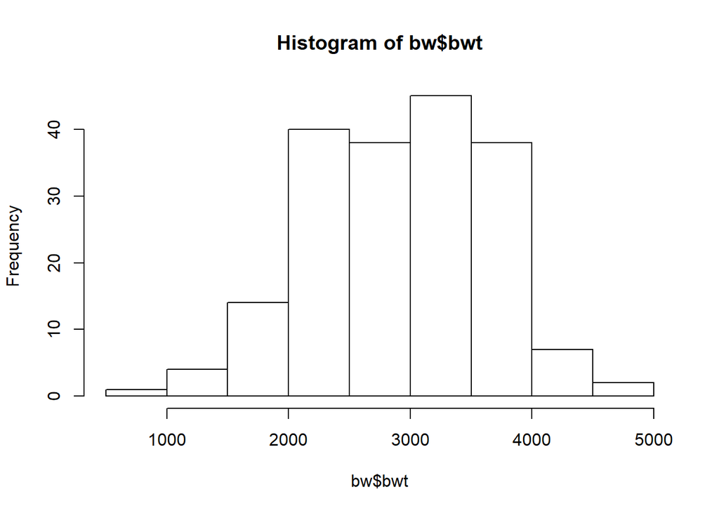

```r
hist(bw$bwt)
```

Um passo importante antes de começar a aplicar um modelo de árvore de decisão é converter variáveis categóricas em fatores.

```r
cols <- c('low', 'race', 'smoke', 'ht', 'ui')
bw[cols] <- lapply(bw[cols], as.factor)
```

Para construir o modelo divide-se os dados em dados de treinamento e dados de teste. Neste caso, escolheu-se 70% para os de treinamento e 30% para teste. Os dados de treinamento são os que serão utilizados para construir o modelo de *machine learning*, e os de teste para analisar a performance do modelo.

```r
set.seed(123)

train.index <- sample((nrow(bw)),0.7*nrow(bw))

train <- bw[train.index,]
test  <- bw[-train.index,]
```

A construção da árvore é feita usando *rpart*. Como já existe a variável *low* que indica se o peso é baixo, não será utilizada a variável *bwt* de todos os pesos.

```r
fit <- rpart(low ~ age + lwt + race + smoke + ptl + ht +
               ui + ftv,
             data=train,
             method="class")
summary(fit)
```

```
## Call:
## rpart(formula = low ~ age + lwt + race + smoke + ptl + ht + ui +
##     ftv, data = train, method = "class")
##   n= 132
##
##          CP nsplit rel error    xerror      xstd
## 1 0.2051282      0 1.0000000 1.0000000 0.1344071
## 2 0.0100000      1 0.7948718 0.8461538 0.1275625
##
## Variable importance
## ptl
## 100
##
## Node number 1: 132 observations,    complexity param=0.2051282
##   predicted class=0  expected loss=0.2954545  P(node) =1
##     class counts:    93    39
##    probabilities: 0.705 0.295
##   left son=2 (114 obs) right son=3 (18 obs)
##   Primary splits:
##       ptl  < 0.5  to the left,  improve=7.591972, (0 missing)
##       lwt  < 106  to the right, improve=3.556397, (0 missing)
##       ui   splits as  LR,       improve=3.300000, (0 missing)
##       race splits as  LRR,      improve=2.428278, (0 missing)
##       age  < 27.5 to the right, improve=1.704545, (0 missing)
##
## Node number 2: 114 observations
##   predicted class=0  expected loss=0.2280702  P(node) =0.8636364
##     class counts:    88    26
##    probabilities: 0.772 0.228
##
## Node number 3: 18 observations
##   predicted class=1  expected loss=0.2777778  P(node) =0.1363636
##     class counts:     5    13
##    probabilities: 0.278 0.722
```

Com os dados de teste, podemos checar o modelo e conferir a precisão dele em acertar as previsões.

```r
prediction <- predict(fit, test, type = "class")
table(prediction,test$low)
```

```
##
## prediction  0  1
##          0 30 15
##          1  7  5
```

```r
prop.table(table(prediction,test$low))
```

```
##
## prediction         0         1
##          0 0.5263158 0.2631579
##          1 0.1228070 0.0877193
```

Este modelo inicial resolta em um precisão de 0.5263158 mais 0.0877193, ou seja, uma precisão de 0.614, que não é um bom valor.

Para construir uma árvore maior e tentar obter uma precisão maior podemos usar *minsplit*.

```r
fit <- rpart(low ~ age + lwt + race + smoke + ptl + ht +
               ui + ftv,
             data=train,
             method="class",
             minsplit = 2, cp = 0
             )
prediction <- predict(fit, test, type = "class")
table(prediction,test$low)
```

```
##
## prediction  0  1
##          0 26 10
##          1 11 10
```

```r
prop.table(table(prediction,test$low))
```

```
##
## prediction         0         1
##          0 0.4561404 0.1754386
##          1 0.1929825 0.1754386
```

Observa-se que os resultados foram melhores, com uma precisão de acerto de 0,631. Porém esse valor ainda é baixo.